# Taller 6

Métodos Computacionales para Políticas Públicas - URosario

**Entrega: viernes 27-sep-2019 11:59 PM**

**Juan Camilo Salgado Ramírez**  
juanca.salgado@urosario.edu.co

## Instrucciones:

- Guarde una copia de este *Jupyter Notebook* en su computador, idealmente en una carpeta destinada al material del curso.
- Modifique el nombre del archivo del *notebook*, agregando al final un guión inferior y su nombre y apellido, separados estos últimos por otro guión inferior. Por ejemplo, mi *notebook* se llamaría: mcpp_taller6_santiago_matallana
- Marque el *notebook* con su nombre y e-mail en el bloque verde arriba. Reemplace el texto "[Su nombre acá]" con su nombre y apellido. Similar para su e-mail.
- Desarrolle la totalidad del taller sobre este *notebook*, insertando las celdas que sea necesario debajo de cada pregunta. Haga buen uso de las celdas para código y de las celdas tipo *markdown* según el caso.
- Recuerde salvar periódicamente sus avances.
- Cuando termine el taller:
  1. Descárguelo en PDF. Si tiene algún problema con la conversión, descárguelo en HTML.
  2. Suba todos los archivos a su repositorio en GitHub, en una carpeta destinada exclusivamente para este taller, antes de la fecha y hora límites.

(Todos los ejercicios tienen el mismo valor.)

### Resuelva la parte 1 de [este documento](http://www.math.pitt.edu/~sussmanm/3040Summer14/exercisesII.pdf).

### Exercise 7: Numpy practice (5 points)

Start up Python (best to use Spyder) and use it to answer the following questions. Use the following imports:

```python
import numpy as np
import scipy.linalg as la
import matplotlib.pyplot as plt
```

1. Choose a value and set the variable 'x' to that value

```python
x = 7
```

1. What is command to compute the square ofx? Its cube?

```python
print(x)

# Square:
print(x**2)

# Cube:
print(x**3)
```

```
7
49
343
```

1. Choose an angle 'θ' and set the variable theta to its value (a number).

```python
theta = 30
```

1. What is sin 'θ'? cos 'θ'? Angles can be measured in degrees or radians. Which of these are being used used?

```python
# sin 'θ'
print(np.sin(theta))

# cos 'θ'
print(np.cos(theta))

# np.sin()/np.cos() utiliza los angulos en radianes.
# Si usara en grados:
# np.sin(30) = 0.5
# np.cos(30) = 0.866025
# pero como usa radianes los valores son distintos
```

```
-0.9880316240928618
0.15425144988758405
```

1. Use the np.linspace function to create a row vector called meshPoints containing exactly 500 values with values evenly spaced between -1 and 1.

```python
meshPoints = np.linspace(-1, 1, 500)
```

1. What expression will yield the value of the 53th element of meshPoints? What is this value?

```python
# Como se requiere el valor numero 53, y python inexa base cero, se debe filtrar el numero 52:
meshPoints[52]
```

```
-0.7915831663326653
```

1. Produce a plot of a sinusoid on the interval [−1,1] using the command plt.plot(meshPoints,np.sin(2*pi*meshPoints)) Please save this plot as a jpeg (.jpg) file and send it along with your work.

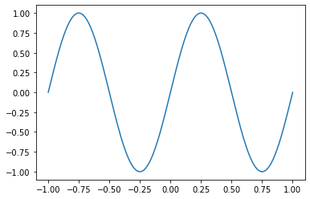

```python
# el comando esta erroneo en 'pi': debe ser np.pi
plt.plot(meshPoints,np.sin(2*np.pi*meshPoints))
plt.savefig('Figure 1.jpg')
```

### Resuelva los ejercicios de las secciones 4.1, 5.1, 6.1, 7.4 y 8.5 de [este documento](http://www.python-academy.com/download/pycon2012/matplotlib_handout.pdf).

### 4.1 Exercises

1. Plot a simple graph of a sinus function in the range 0 to 3 with a step size of 0.01.

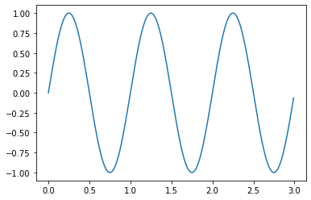

```python
# Generar variable entre el rango con el espacio requerido
variable = np.arange(0, 3, 0.01)
plt.plot(variable,np.sin(2*np.pi*variable))
```

1. Make the line red. Add diamond-shaped markers with size of 5.

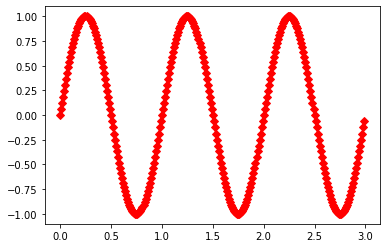

```python
plt.plot(variable,np.sin(2*np.pi*variable), color = "red", marker = "D", markersize = 5)
```

1. Add a legend and a grid to the plot.

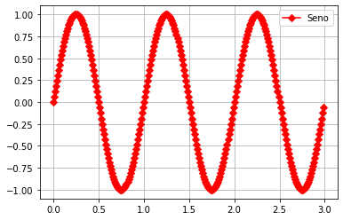

```python
plt.plot(variable,np.sin(2*np.pi*variable), color = "red", marker = "D", markersize = 5, label = 'Seno')
plt.legend()
plt.grid();
```

### 5.1 Exercise

1. Apply different line styles to a plot. Change line color and thickness as well as the size and the kind ofthe marker. Experiment with different styles.

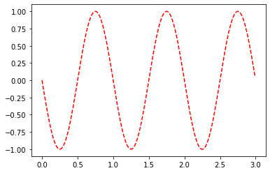

```python
plt.plot(variable,np.sin(-2*np.pi*variable), color = "red", linestyle = '--')
```

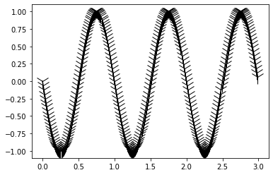

```python
plt.plot(variable,np.sin(-2*np.pi*variable), color = "black", marker = "1", markersize = 20)
```

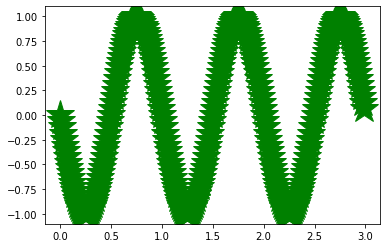

```python
plt.plot(variable,np.sin(-2*np.pi*variable), color = "green", marker = "*", markersize = 30, linewidth=7.0)
```